# Prac for Gaussian Processes

STA5090Z

Published

August 13, 2026

## Simulating from a Gaussian Process

- squared exponential kernel
- mean function = 0
- $\ell$ = 0.5
- $\sigma_f = 1$
- $\sigma_e = 0$

```r
library(mvtnorm)
set.seed(1)
x <- seq(0, 10, length = 100)
d = abs(outer(x, x, "-")) # compute distance matrix, d_{ij} = |x_i - x_j|
mx <- rep(0, times = 100)

Sigma_SE = exp(-d^2 / (2 * 0.5^2)) # squared exponential kernel
y = mvtnorm::rmvnorm(1, mean = mx, sigma = Sigma_SE)
```

- plot 5 simulated functions on one plot, add the mean function
- generate 20 equally spaced values and add as points to above plot
- add observation error
- change the mean function (e.g. trend or quadratic polynomial)

## Fit and Simulate from Posterior

Data from Schulz Table 2

```r
tt <- 1:6
xt <- c(0.9, 3.8, 5.2, 6.1, 7.5, 9.6)
yt <- c(0.1, 1.2, 2.1, 1.1, 1.5, 1.2)
```

- fit a Gaussian process using Maximum Marginal Likelihood
- simulate from posterior and illustrate

## Problem 1

Use a Bayesian approach to fit a Gaussian process model to the data in the previous question. Simulate from the posterior and illustrate.

Carefully explain what the Stan code does (`gp1.stan`). Use equations.

## Question 2

Suppose we model the relationship of a real-valued response variable, $y$, to a single real input, $x$, using a Gaussian process model in which the mean is zero and the covariances of the observed responses are given by

$Cov(y_i, y_{i'}) = 0.5^2 \delta_{i,i'} + K(x_i, x_{i'})$

with the noise-free covariance function, K, defined by

$$K(x, x') = \begin{cases}
1 − |x − x′| & \text{if } |x − x′| < 1 \\
0 & \text{otherwise}
\end{cases}$$

Suppose we have four training cases, as follows:

| x | y |
| --- | --- |
| 0.5 | 2.0 |
| 2.8 | 3.3 |
| 1.6 | 3.0 |
| 3.9 | 2.7 |

Recall that the conditional mean of the response in a test case with input $x∗$, given the responses in the training cases, is $k^T C^{−1}y$, where $y$ is the vector of training responses, $C$ is the covariance matrix of training responses, and $k$ is the vector of covariances of training responses with the response in the test case.

Find the predictive mean for the response in a test case in which the input is $x^∗ = 1.2$.

## Problem 2

Below are five functions randomly drawn from five different Gaussian processes. For all five Gaussian processes, the mean function is zero. The covariance functions are one of those listed below.

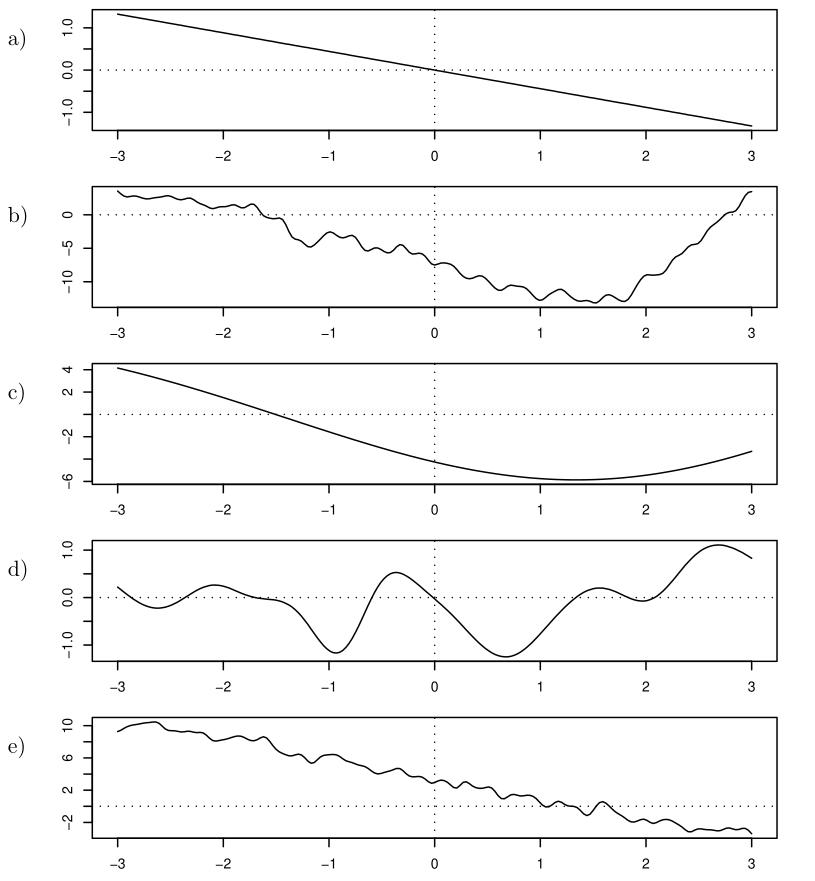

For each of the five covariance functions below, indicate which of the five functions above is most likely to have been drawn from the Gaussian process with that covariance function.

1.) $\text{Cov}(y_{i_1} , y_{i_2} ) = 0.5^2 \exp( − ((x_{i_1} − x_{i_2} ) / 0.5)^2 )$

2.) $\text{Cov}(y_{i_1} , y_{i_2} ) = x_{i_1} x_{i_2}$

3.) $\text{Cov}(y_{i_1} , y_{i_2} ) = 5^2 + 5^2 x_{i_1} x_{i_2} + 0.5^2 \exp( − ((x_{i_1} − x_{i_2} ) / 0.1)^2 )$

4.) $\text{Cov}(y_{i_1} , y_{i_2} ) = 0.7^2 \exp( − ((x_{i_1} − x_{i_2} ) / 0.1)^2 ) + 8^2 \exp( − ((x_{i_1} − x_{i_2} ) / 2)^2 )$

5.) $\text{Cov}(y_{i_1} , y_{i_2} ) = 8^2 \exp( − ((x_{i_1} − x_{i_2} ) / 5)^2 )$

## Problem 3

Recall that for a Gaussian process model the predictive distribution for the response $y^∗$ in a test case with inputs $x^∗$ has mean and variance given by

$$E[y^∗ | x^∗ , x, y] = k^T C^{−1} y$$

$$Var[y^∗ | x^∗ , x, y] = v − k^T C^{−1} k$$

where $y$ is the vector of observed responses in training cases, $C$ is the matrix of covariances for the responses in training cases, $k$ is the vector of covariances of the response in the test case with the responses in training cases, and $v$ is the prior variance of the response in the test case.

1. Suppose we have just one training case, with $x_1 = 3$ and $y_1 = 4$. Suppose also that the noise-free covariance function is $K(x, x′ ) = 2^{−|x−x|}$, and the variance of the noise is $1/2$.

   Find the mean and variance of the predictive distribution for the response in a test case for which the value of the input is $5$.
2. Repeat the calculations for (a), but using $K(x, x′ ) = 2^{+|x−x|}$ . What can you conclude from the result of this calculation?